# Pareto EFS

Zahra Mungloo-Dilmohamud

3/18/2022

## Step 4. Optimise the selected criteria.

In this step, the performance values and the stability metrics calculated in Step 3 as well as the number of base methods to produce the list are optimised using the pareto dominance. The subset of features ranking highest will be selected since they represent the subset giving the best stability while being the most performing.

Load all packages

```r
options(warn=-1)
library(dplyr)
options(warn=0)
```

Read the file containing the performance, stability and number of FS methods used to produce the merged lists

```r
data_criteria_4_39582 <- read.csv('39582/Stability_Performance_39582_10_repeats_v2.csv', header = TRUE)
```

```r
num_rows <- nrow(data_criteria_4_39582)

dominates_matrix_4_39582 <- data.frame(
  Doubles=double(),
  Doubles=double(),
  stringsAsFactors=FALSE
)
names(dominates_matrix_4_39582)[1] <- "dominates"
names(dominates_matrix_4_39582)[2] <- "dominated"

dominates_matrix_4_39582_sorted <- data.frame(
  Doubles=double(),
  Doubles=double(),
  stringsAsFactors=FALSE
)

dominates_matrix_4_39582_freq <- data.frame(
  Doubles=double(),
  Doubles=double(),
  stringsAsFactors=FALSE
)

dominated_matrix_4_39582_freq <- data.frame(
  Doubles=double(),
  Doubles=double(),
  stringsAsFactors=FALSE
)

merge_matrix_4_39582_freq <- data.frame(
  Doubles=double(),
  Doubles=double(),
  Doubles=double(),
  Doubles=double(),
  stringsAsFactors=FALSE
)


# # For every possibility - every row in the file
 for(j in 1:num_rows){
   if(j+1<=num_rows){
   # print(j)
   # print("******************")
   for(i in j:(num_rows-1)){
     if (data_criteria_4_39582[j,2]==data_criteria_4_39582[i+1,2] && data_criteria_4_39582[j,6]==data_criteria_4_39582[i+1,6]&& data_criteria_4_39582[j,7]==data_criteria_4_39582[i+1,7]&& data_criteria_4_39582[j,8]==data_criteria_4_39582[i+1,8]){

     }
     else if (data_criteria_4_39582[j,2]>=data_criteria_4_39582[i+1,2] & data_criteria_4_39582[j,6]>=data_criteria_4_39582[i+1,6] & data_criteria_4_39582[j,7]>=data_criteria_4_39582[i+1,7] & data_criteria_4_39582[j,8]>=data_criteria_4_39582[i+1,8]){

     dominates_matrix_4_39582[nrow(dominates_matrix_4_39582) + 1,] = list(j,i+1)
     }
     else if(data_criteria_4_39582[i+1,2]>=data_criteria_4_39582[j,2] & data_criteria_4_39582[i+1,6]>=data_criteria_4_39582[j,6]& data_criteria_4_39582[i+1,7]>=data_criteria_4_39582[j,7]& data_criteria_4_39582[i+1,8]>=data_criteria_4_39582[j,8]){

     dominates_matrix_4_39582[nrow(dominates_matrix_4_39582) + 1,] = list(i+1,j)
     } #end of else

   } #end for i

   } #end of if j+1
   # print("******************")
 }

dominates_matrix_4_39582_sorted <- dominates_matrix_4_39582[order(dominates_matrix_4_39582$dominates),]
write.table(dominates_matrix_4_39582,"39582/results/39582_4_metrics_sorted_train_test_10_repeats.csv", sep = ",", row.names = FALSE)

dominates_matrix_4_39582_freq <- as.data.frame(table(dominates_matrix_4_39582_sorted$dominates))
dominated_matrix_4_39582_freq <- as.data.frame(table(dominates_matrix_4_39582_sorted$dominated))

names(dominates_matrix_4_39582_freq)[1]<-"row_number"
names(dominates_matrix_4_39582_freq)[2]<-"frequency"
names(dominated_matrix_4_39582_freq)[1]<-"row_number"
names(dominated_matrix_4_39582_freq)[2]<-"frequency"

merge_matrix_4_39582_freq<- full_join(dominates_matrix_4_39582_freq, dominated_matrix_4_39582_freq, by = "row_number")

merge_matrix_4_39582_freq[is.na(merge_matrix_4_39582_freq)] <- 0

names(merge_matrix_4_39582_freq)[1]<-"row_number"
names(merge_matrix_4_39582_freq)[2]<-"dominates_freq"
names(merge_matrix_4_39582_freq)[3]<-"isDominated_freq"

merge_matrix_4_39582_freq$scalar_score <-merge_matrix_4_39582_freq$dominates_freq - merge_matrix_4_39582_freq$isDominated_freq
names(merge_matrix_4_39582_freq)[4]<-"scalar_score"

write.table(merge_matrix_4_39582_freq,"39582/results/39582_4_metrics_10_repeats.csv", sep = ",", row.names = FALSE)
```

We now have a file containing the pareto for the 26 merged lists.

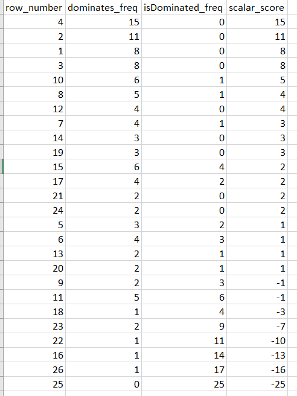

In this example, after performing the above steps, it was found that the Row_number 4, consisting of feature subsets from methods Correlation Feature Selection, ReliefF, SAM, and SVM, ranked first. Based on the number of feature subsets that it dominates, it seems to be best by far both in terms of stability and performance. Furthermore, resulting from the merging of 4 different methods it is also composed of diverse features hence meeting all the expected criteria of the feature subset. However, Row_number 4 represents the average of 10 different experiments/feature subsets. The next step is to choose 1 feature subset out of the 10.

| Step 3. | Step 5. |
| --- | --- |